# Propser Loan Data Exploration

## Mohamed Salem Ali

## ( Structure of Dataset )

## The dataset comprised of borrower APRs and traits of 113,937 advances.Most variables are numeric and categorical. The credits included original loan amount. borrower's Prosper rating advance term. borrower's expressed month to month pay. just as numerous different elements like borrower's work status relationship of outstanding debt to take home pay. current advance status and so forth.

## ( Main features of interest )

## 1- Borrower Annual Percentage Rate.....2- LoanOriginalAmount

## 3- StatedMonthlyIncome..........................4- Estimated Returns

# Univariate Exploration

### We'll start with taking a look at BorrowerAPR.

## 1-BorrowerAPR

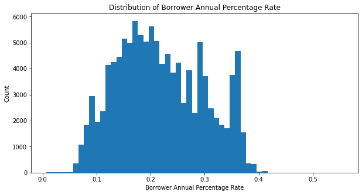

```python
B_APR = df.BorrowerAPR
b = np.arange(B_APR.min(),B_APR.max()+0.05,0.01)
plt.figure(figsize=[10,5])
plt.hist(data = df, x = 'BorrowerAPR', bins=b)
plt.xlabel('Borrower Annual Percentage Rate')
plt.ylabel('Count')
plt.title('Distribution of Borrower Annual Percentage Rate');
```

## A small peak centered at 0.1, a large peak centered at 0.2. There is also a small peak centered 0.3. Additionally, there is a very shape peak between 0.35 and 0.36. Only very few loans have APR greater than 0.43.

### Let's continue our exploration, We'll start with taking a look at Loan Original Amount

## 2-Loan Original Amount

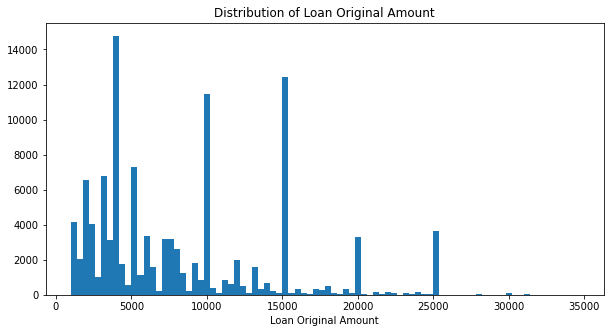

```python
b = np.arange(LOA.min(),LOA.max(),400)
plt.figure(figsize=[10,5])
plt.hist(data = df, x = 'LoanOriginalAmount', bins=b)
plt.xlabel('Loan Original Amount')
plt.title('Distribution of Loan Original Amount');
```

### Large frequency at 4000 , 10000, 15000 , 20000 , 25000

### Small frequency less than 4000 and between (5000 , 10000) and between (10000, 15000)

### Let's continue our exploration, We'll start with taking a look at State Monthly Income

## 3-State Monthly Income

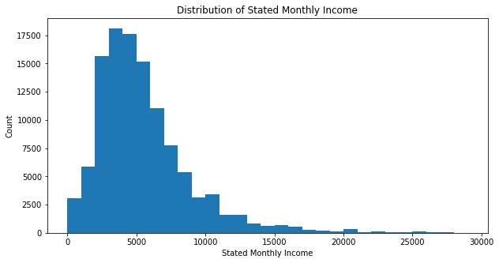

```python
SMI = df.StatedMonthlyIncome
b = np.arange(0,30000,1000)
plt.figure(figsize=[10,5])
plt.hist(data = df, x = 'StatedMonthlyIncome', bins=b)
plt.xlabel('Stated Monthly Income')
plt.ylabel('Count')
plt.title('Distribution of Stated Monthly Income');
```

## The distribution of stated monthly income is severely right screwed, with most of stated monthly income less than 30k , The Most Stated Monthly Income between (3500 , 7000)

### Let's continue our exploration, We'll start with taking a look at Estimated Returns

## 4- Estimated Returns

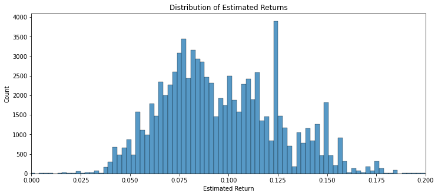

```python
plt.figure(figsize = [12,5])
sb.histplot(ER, bins = 200)
plt.xlim(0, .2)
plt.xlabel('Estimated Return')
plt.ylabel('Count')
plt.title('Distribution of Estimated Returns');
```

## the distribution is right skewed.

### Most of our loans have an estimated return between 0% and 20% . It also looks like there are some peaks in some standard values such as 5%, 7.5%, 12.5%, and 15%. Most curiously the largest bin falls right around 12.5%.

# Bivariate Exploration

### Let's continue our exploration with Loan Original Amount , Borrower APR, Stated Monthly Income

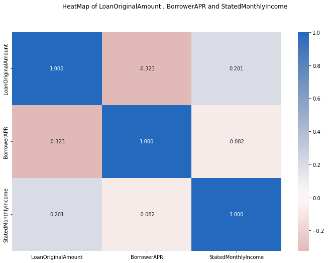

```python
HeatMap(numeric_variables_1 , [12, 8] , "HeatMap of LoanOriginalAmount , BorrowerAPR and StatedMonthlyIncome")
```

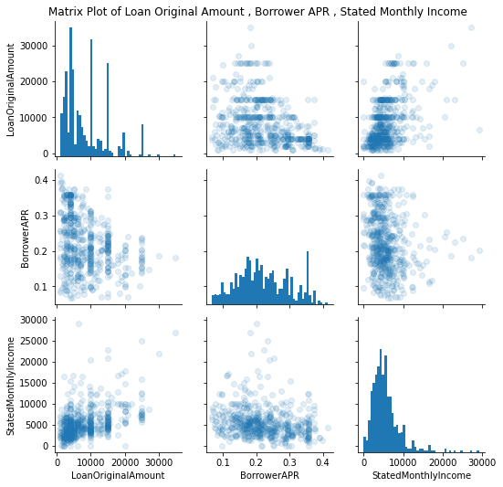

```python
samples = np.random.choice(df.shape[0], int(df.shape[0]*.005), replace = False)
df_samp = df.loc[samples,:]
g = sb.PairGrid(data = df_samp, vars = numeric_variables_1)
g = g.map_diag(plt.hist, bins = 50)
g.map_offdiag(plt.scatter, alpha = 1/8)
g.fig.suptitle('Matrix Plot of Loan Original Amount , Borrower APR , Stated Monthly Income')
g.fig.subplots_adjust(top = .95);
```

### The correlation coefficient of borrower APR and loan original amount is Negative, that is the more the loan amount, the lower the APR.

### The loan original amount is positively correlated with the stated monthly income, it makes sense since borrowers with more monthly income could loan more money.

## Let's continue to explore this thread by also plotting the credit score along with the income range.

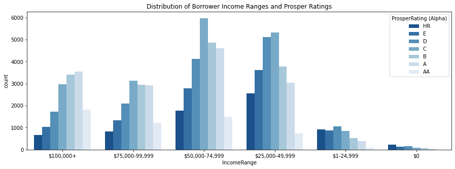

```python
ClusteredChart(df,[15,5],'IncomeRange','ProsperRating (Alpha)','Distribution of Borrower Income Ranges and Prosper Ratings')
```

### higher incomes correlate to a higher credit rating qualifying the borrower for the best (lowest) interest rates.Having an income of 75k+ doesn't automatically guarantee the best credit ratings. I'm curious to see in the multivariate analysis what other factors play a big role in determining one's credit rating

# Multivariate Exploration

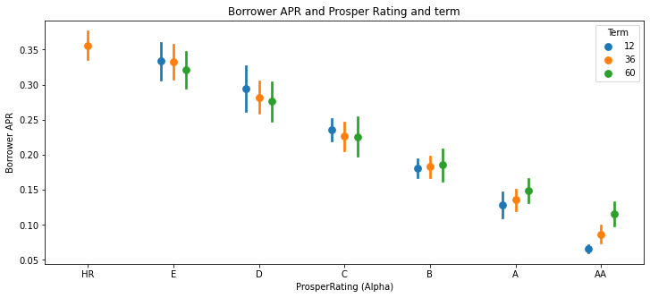

```python
fig = plt.figure(figsize = [12,5])
ax = sb.pointplot(data = df, x = 'ProsperRating (Alpha)', y = 'BorrowerAPR', hue = 'Term',linestyles = '', dodge = 0.3, ci='sd')
plt.title('Borrower APR and Prosper Rating and term')
plt.ylabel('Borrower APR')
ax.set_yticklabels([],minor = True);
```

### the borrower APR decrease with the increase of borrow term for people with HR-D raing and the borrower APR increase with the increase of borrow term for people with A-AA raings and the borrower APR still much the same with the increase of borrow term for people with C and B raings